# Children & HIV: The Fight for Treatment Access

Author

Abdul Shajath Mirzha Lafir

**The Global Challenge: Protecting the Next Generation**

Despite significant medical advancements, HIV remains a critical threat to children globally. While adult treatment rates have improved, pediatric care often lags behind. This report explores the current landscape of ART (Antiretroviral Therapy) coverage and the persistent disparities in child health outcomes.

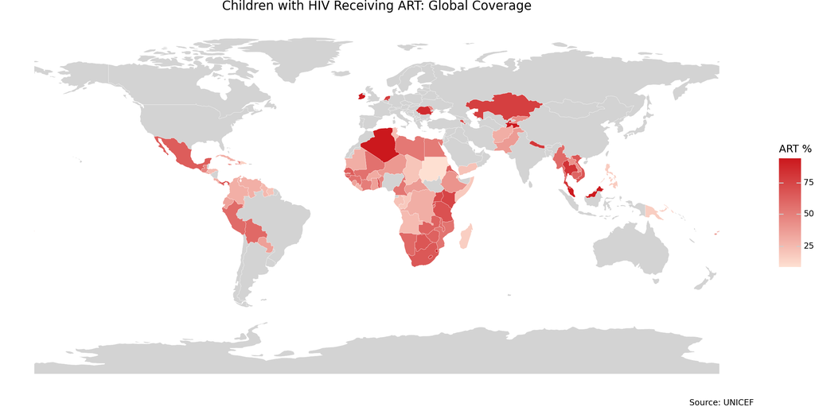

Figure 1: ART coverage for children (0-14) with HIV: latest year per country

**Progress Over Time: Are We Moving Fast Enough?**

The data shows a clear upward trend in treatment coverage over the last decade. As global health initiatives have scaled up, more children than ever are receiving life-saving medication. However, the “slope” of this progress suggests that we are still years away from universal coverage. The variation between countries remains high, meaning a child’s survival often depends on where they are born.

[figure not shown]

Figure 2: 15 countries with the lowest ART coverage for children

**The Geography of Inequality**

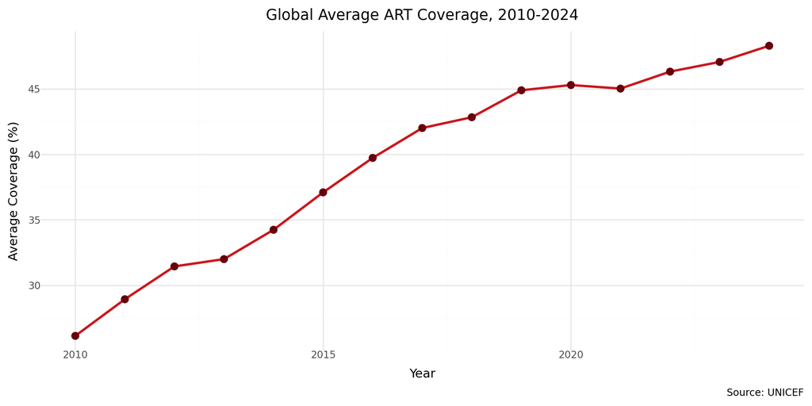

Figure 3: Global average ART coverage trend, 2010-2024

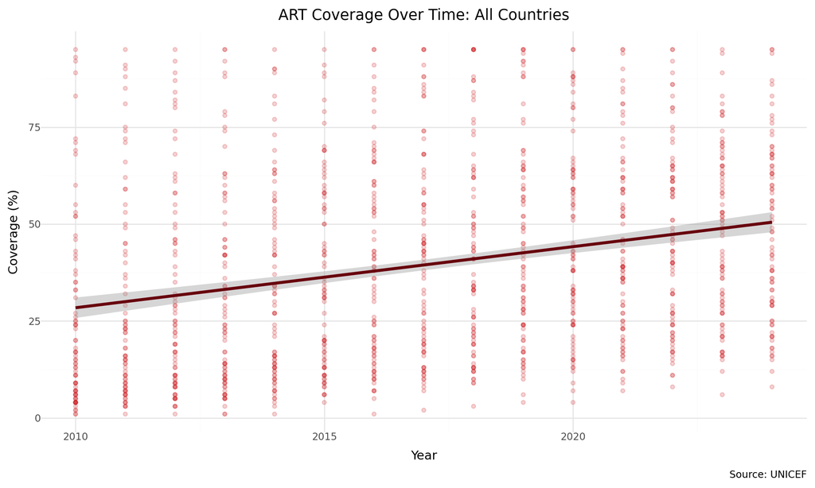

Figure 4: ART coverage over time with linear regression: all countries

**Conclusion: Beyond the Numbers**

Data tells us that we have the tools to end pediatric AIDS, but the coverage gaps show we lack the universal implementation to do so. To reach the goal of an AIDS-free generation, global efforts must focus on:

Early Diagnosis: Identifying HIV-positive infants in the first weeks of life.

Sustainable Funding: Ensuring treatment isn’t interrupted by economic shifts.

Equity: Closing the gap between adult and pediatric treatment rates.

The numbers represent lives. Every percentage point increase in coverage is thousands of children given the chance to grow into adulthood.